# NYPD_Shooting_Basic_Exploration

### Jurisdiction Code

```r
table(df$JURISDICTION_CODE)
```

```
##
##     0     1     2
## 22809    74  4427
```

```r
#according to NYC's data website, 0=Patrol, 1=Transit, 2=Housing
```

### “LOC_CLASSFCTN_DESC”

```r
table(df$LOC_CLASSFCTN_DESC)
```

```
##
##              COMMERCIAL    DWELLING     HOUSING       OTHER PARKING LOT
##       25596         100         127         280          31           7
##  PLAYGROUND      STREET     TRANSIT     VEHICLE
##          30        1103          15          23
```

```r
#vast majority have missing value
```

### “LOCATION_DESC”

```r
table(df$LOCATION_DESC)
```

```
##
##                                              (null)                       ATM
##                     14977                       977                         1
##                      BANK            BAR/NIGHT CLUB         BEAUTY/NAIL SALON
##                         3                       628                       112
##               CANDY STORE               CHAIN STORE                CHECK CASH
##                         7                         5                         1
##         CLOTHING BOUTIQUE           COMMERCIAL BLDG                DEPT STORE
##                        14                       292                         9
##            DOCTOR/DENTIST                DRUG STORE       DRY CLEANER/LAUNDRY
##                         1                        14                        31
##         FACTORY/WAREHOUSE                 FAST FOOD               GAS STATION
##                         8                       104                        71
##            GROCERY/BODEGA      GYM/FITNESS FACILITY                  HOSPITAL
##                       694                         3                        65
##               HOTEL/MOTEL             JEWELRY STORE              LIQUOR STORE
##                        35                        12                        41
##              LOAN COMPANY   MULTI DWELL - APT BUILD MULTI DWELL - PUBLIC HOUS
##                         1                      2835                      4832
##                      NONE          PHOTO/COPY STORE                 PVT HOUSE
##                       175                         1                       951
##          RESTAURANT/DINER                    SCHOOL                SHOE STORE
##                       204                         1                        10
##            SMALL MERCHANT SOCIAL CLUB/POLICY LOCATI          STORAGE FACILITY
##                        37                        72                         1
##        STORE UNCLASSIFIED               SUPERMARKET           TELECOMM. STORE
##                        36                        21                        11
##             VARIETY STORE               VIDEO STORE
##                        11                         8
```

```r
#interesting categories here but more than half still have missing value
```

### STATISTICAL_MURDER_FLAG

```r
table(df$STATISTICAL_MURDER_FLAG)
```

```
##
## false  true
## 22046  5266
```

```r
# from NYC's data website: "Shooting resulted in the victim’s death which would be counted as a murder"
```

### Shooter Age/Sex/Race

```r
table(df$PERP_AGE_GROUP)
```

```
##
##          (null)     <18    1020   18-24     224   25-44   45-64     65+     940
##    9344     640    1591       1    6222       1    5687     617      60       1
## UNKNOWN
##    3148
```

```r
table(df$PERP_SEX)
```

```
##
##        (null)      F      M      U
##   9310    640    424  15439   1499
```

```r
table(df$PERP_RACE)
```

```
##
##                                                        (null)
##                           9310                            640
## AMERICAN INDIAN/ALASKAN NATIVE       ASIAN / PACIFIC ISLANDER
##                              2                            154
##                          BLACK                 BLACK HISPANIC
##                          11432                           1314
##                        UNKNOWN                          WHITE
##                           1836                            283
##                 WHITE HISPANIC
##                           2341
```

```r
#naturally there is a substantial proportion of missing values. Presumably police can't necessarily even get good witness staments to go off of in many instances
#typical profile of categorized shooter is young, male, black/hispanic
#based on number of null/missing values it looks like a perp description (i.e. these columns in a single row) is generally either fully filled or fully blank
```

### Victim Age/Sex/Race

```r
table(df$VIC_AGE_GROUP)
```

```
##
##     <18    1022   18-24   25-44   45-64     65+ UNKNOWN
##    2839       1   10086   12281    1863     181      61
```

```r
table(df$VIC_SEX)
```

```
##
##     F     M     U
##  2615 24686    11
```

```r
table(df$VIC_RACE)
```

```
##
## AMERICAN INDIAN/ALASKAN NATIVE       ASIAN / PACIFIC ISLANDER
##                             10                            404
##                          BLACK                 BLACK HISPANIC
##                          19439                           2646
##                        UNKNOWN                          WHITE
##                             66                            698
##                 WHITE HISPANIC
##                           4049
```

```r
#naturally victims have many fewer missing values (they got shot, much easier to find)
#profile again is young, male, black/hispanic
```

### Geolocation Data - [needs to be visualized with geographical package]

### Modeling fatality proportion vs precinct number of shootings

#### A typical question that arises from examining crime data is whether police/emergency resources are being fairly distributed throughout a jurisdiction. While we don’t have any sort of deployment or response time data here for NYPD we can check to see if there is any relationship between the number of shootings in a precinct and the proportion that are fatal as a sort of proxy for the speed/efficacy of emergency response in general.

```r
#create a dataframe with each princinct's shooting count, fatality count, and proportion of shootings that are fatal
df$Fatal = df$STATISTICAL_MURDER_FLAG %>% recode('true' = 1, 'false' = 0)
fatality_prop_df = df %>% group_by(PRECINCT) %>% summarise(Count = n(), Fatalities = sum(Fatal), Fatal_prop = mean(Fatal))
fatality_prop_df %>% head(5)
```

```
## # A tibble: 5 × 4
##   PRECINCT Count Fatalities Fatal_prop
##      <int> <int>      <dbl>      <dbl>
## 1        1    25          7     0.28
## 2        5    58         17     0.293
## 3        6    28          6     0.214
## 4        7   109          9     0.0826
## 5        9   109         25     0.229
```

```r
#Calculate linear model with x=number of shootings in a precinct and y=proportion of shootings that are fatal
#As we can see from the model and the graph below there is essentially no correlation,
#so there is no suggestion *in this data* that more dangerous precincts are experiencing a generally worse or better shooting
#emergency response.
model = lm(formula = Fatal_prop ~ Count, data = fatality_prop_df, )
summary(model)
```

```
##
## Call:
## lm(formula = Fatal_prop ~ Count, data = fatality_prop_df)
##
## Residuals:
##       Min        1Q    Median        3Q       Max
## -0.201298 -0.024434 -0.002226  0.027257  0.209253
##
## Coefficients:
##               Estimate Std. Error t value Pr(>|t|)
## (Intercept)  2.013e-01  9.720e-03  20.711   <2e-16 ***
## Count       -1.192e-05  1.932e-05  -0.617    0.539
## ---
## Signif. codes:  0 '***' 0.001 '**' 0.01 '*' 0.05 '.' 0.1 ' ' 1
##
## Residual standard error: 0.06047 on 75 degrees of freedom
## Multiple R-squared:  0.005046,   Adjusted R-squared:  -0.00822
## F-statistic: 0.3804 on 1 and 75 DF,  p-value: 0.5393
```

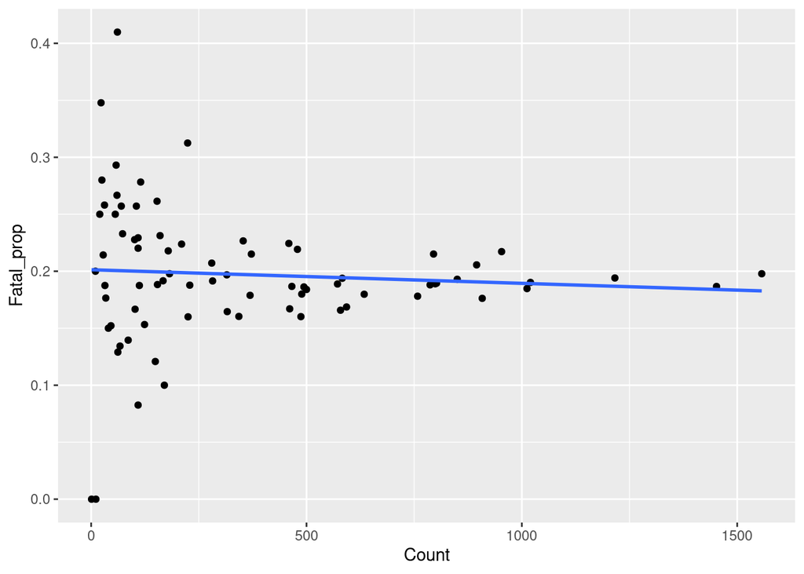

```r
ggplot(fatality_prop_df, aes(x = Count, y = Fatal_prop)) + geom_point() + geom_smooth(method = 'lm', se = F)
```

## Data Bias and Quality Discussion

- It is not clear whether this data includes instances where people literally were hit with a bullet or if there are also incidents where a victim was just shot at; either way there are presumably more ‘shots fired’ incidents not included in this data set which have different feature distributions from this dataset
- A lot of the location description columns are missing so many values that they are not particularly useful
- Perpetrator description columns may be subject to direct bias as they may be garnered from witness statements which can be faulty
- Victim description columns should be better since it is easier to actually locate and confirm a shooting victim